# Divvy Exercise Full Year Analysis

Cassiano Oliveira

2024-03-24

### **Setting up my environment.**

Notes: This analysis is based on the **Divvy case study** “‘Sophisticated, Clear, and Polished’: Divvy and Data Visualization” written by [Kevin Hartman](https://artscience.blog/home/divvy-dataviz-case-study).

The purpose of ths script is to consolidate downloaded Divvy data into a single data frame and then conduct simple analysis to help answer the key question:**In what ways do members and casual riders use Divvy bikes differently?**

The data is mad available by [Motivate International Inc](https://divvybikes.com/data-license-agreement). This is public data that can be used to explore how different types of customers are using Cyclistic bikes. However, due to data privacy, using passengers’ personally identifiable information is prohibited.

[figure not shown]

Source:https://artscience.blog/.

#### The following packages are required to run the code and reproduce the results:

- `tidyverse` for data import and wrangling.
- `lubridate` for date functions.
- `ggplot` for visualization.
- `dplyr` Data manipulation library with a focus on data frames.
- `readr` for reading and writing structured text files.
- `hms` for representing and manipulating periods of time.
- `tibble` Modern alternative to data frames.
- `doBy` for grouping and summarizing data.

##### Loading packages.

```r
library(tidyverse)
```

```r
library(lubridate)
library(ggplot2)
library(dplyr)
library(readr)
library(hms)
library(tibble)
library(doBy)
setwd("C:/Users/cassi/Documents/R_STUDIO//DIVVY_TRIP_DATA") #I didn't forget the recommendation ;)
```

### **Step 1:** Collect data.

#### Upload Divvy datasets `csv files` here.

```r
dt_2023_03 <- read_csv("C:/Users/cassi/Documents/R_STUDIO/DIVVY_TRIP_DATA/dt_2023_03.csv")
dt_2023_04 <- read_csv("C:/Users/cassi/Documents/R_STUDIO/DIVVY_TRIP_DATA/dt_2023_04.csv")
dt_2023_05 <- read_csv("C:/Users/cassi/Documents/R_STUDIO/DIVVY_TRIP_DATA/dt_2023_05.csv")
dt_2023_06 <- read_csv("C:/Users/cassi/Documents/R_STUDIO/DIVVY_TRIP_DATA/dt_2023_06.csv")
dt_2023_07 <- read_csv("C:/Users/cassi/Documents/R_STUDIO/DIVVY_TRIP_DATA/dt_2023_07.csv")
dt_2023_08 <- read_csv("C:/Users/cassi/Documents/R_STUDIO/DIVVY_TRIP_DATA/dt_2023_08.csv")
dt_2023_09 <- read_csv("C:/Users/cassi/Documents/R_STUDIO/DIVVY_TRIP_DATA/dt_2023_09.csv")
dt_2023_10 <- read_csv("C:/Users/cassi/Documents/R_STUDIO/DIVVY_TRIP_DATA/dt_2023_10.csv")
dt_2023_11 <- read_csv("C:/Users/cassi/Documents/R_STUDIO/DIVVY_TRIP_DATA/dt_2023_11.csv")
dt_2023_12 <- read_csv("C:/Users/cassi/Documents/R_STUDIO/DIVVY_TRIP_DATA/dt_2023_12.csv")
dt_2024_01 <- read_csv("C:/Users/cassi/Documents/R_STUDIO/DIVVY_TRIP_DATA/dt_2024_01.csv")
dt_2024_02 <- read_csv("C:/Users/cassi/Documents/R_STUDIO/DIVVY_TRIP_DATA/dt_2024_02.csv")
```

##### Visualizing the data.

```r
View(dt_2023_03)
View(dt_2023_04)
View(dt_2023_05)
View(dt_2023_06)
View(dt_2023_07)
View(dt_2023_08)
View(dt_2023_09)
View(dt_2023_10)
View(dt_2023_11)
View(dt_2023_12)
View(dt_2024_01)
View(dt_2024_02)
```

### **Step 2:** Combining the data into a single file.

#### The column names of each of the files were compared.

```r
colnames(dt_2023_03)
```

```
##  [1] "ride_id"            "rideable_type"      "started_at"
##  [4] "ended_at"           "start_station_name" "start_station_id"
##  [7] "end_station_name"   "end_station_id"     "start_lat"
## [10] "start_lng"          "end_lat"            "end_lng"
## [13] "member_casual"      "tour_duration"      "day_of_week"
```

```r
colnames(dt_2023_04)
```

```
##  [1] "ride_id"            "rideable_type"      "started_at"
##  [4] "ended_at"           "start_station_name" "start_station_id"
##  [7] "end_station_name"   "end_station_id"     "start_lat"
## [10] "start_lng"          "end_lat"            "end_lng"
## [13] "member_casual"      "tour_duration"      "day_of_week"
```

```r
colnames(dt_2023_05)
```

```
##  [1] "ride_id"            "rideable_type"      "started_at"
##  [4] "ended_at"           "start_station_name" "start_station_id"
##  [7] "end_station_name"   "end_station_id"     "start_lat"
## [10] "start_lng"          "end_lat"            "end_lng"
## [13] "member_casual"      "tour_duration"      "day_of_week"
```

```r
colnames(dt_2023_06)
```

```
##  [1] "ride_id"            "rideable_type"      "started_at"
##  [4] "ended_at"           "start_station_name" "start_station_id"
##  [7] "end_station_name"   "end_station_id"     "start_lat"
## [10] "start_lng"          "end_lat"            "end_lng"
## [13] "member_casual"      "tour_duration"      "day_of_week"
```

```r
colnames(dt_2023_07)
```

```
##  [1] "ride_id"            "rideable_type"      "started_at"
##  [4] "ended_at"           "start_station_name" "start_station_id"
##  [7] "end_station_name"   "end_station_id"     "start_lat"
## [10] "start_lng"          "end_lat"            "end_lng"
## [13] "member_casual"      "tour_duration"      "day_of_week"
```

```r
colnames(dt_2023_08)
```

```
##  [1] "ride_id"            "rideable_type"      "started_at"
##  [4] "ended_at"           "start_station_name" "start_station_id"
##  [7] "end_station_name"   "end_station_id"     "start_lat"
## [10] "start_lng"          "end_lat"            "end_lng"
## [13] "member_casual"      "tour_duration"      "day_of_week"
```

```r
colnames(dt_2023_09)
```

```
##  [1] "ride_id"            "rideable_type"      "started_at"
##  [4] "ended_at"           "start_station_name" "start_station_id"
##  [7] "end_station_name"   "end_station_id"     "start_lat"
## [10] "start_lng"          "end_lat"            "end_lng"
## [13] "member_casual"      "tour_duration"      "day_of_week"
```

```r
colnames(dt_2023_10)
```

```
##  [1] "ride_id"            "rideable_type"      "started_at"
##  [4] "ended_at"           "start_station_name" "start_station_id"
##  [7] "end_station_name"   "end_station_id"     "start_lat"
## [10] "start_lng"          "end_lat"            "end_lng"
## [13] "member_casual"      "tour_duration"      "day_of_week"
```

```r
colnames(dt_2023_11)
```

```
##  [1] "ride_id"            "rideable_type"      "started_at"
##  [4] "ended_at"           "start_station_name" "start_station_id"
##  [7] "end_station_name"   "end_station_id"     "start_lat"
## [10] "start_lng"          "end_lat"            "end_lng"
## [13] "member_casual"      "tour_duration"      "day_of_week"
```

```r
colnames(dt_2023_12)
```

```
##  [1] "ride_id"            "rideable_type"      "started_at"
##  [4] "ended_at"           "start_station_name" "start_station_id"
##  [7] "end_station_name"   "end_station_id"     "start_lat"
## [10] "start_lng"          "end_lat"            "end_lng"
## [13] "member_casual"      "tour_duration"      "day_of_week"
```

```r
colnames(dt_2024_01)
```

```
##  [1] "ride_id"            "rideable_type"      "started_at"
##  [4] "ended_at"           "start_station_name" "start_station_id"
##  [7] "end_station_name"   "end_station_id"     "start_lat"
## [10] "start_lng"          "end_lat"            "end_lng"
## [13] "member_casual"      "tour_duration"      "day_of_week"
```

```r
colnames(dt_2024_02)
```

```
##  [1] "ride_id"            "rideable_type"      "started_at"
##  [4] "ended_at"           "start_station_name" "start_station_id"
##  [7] "end_station_name"   "end_station_id"     "start_lat"
## [10] "start_lng"          "end_lat"            "end_lng"
## [13] "member_casual"      "tour_duration"      "day_of_week"
```

##### List of all your tables.

```r
table_list <- list(dt_2023_03, dt_2023_04, dt_2023_05, dt_2023_06, dt_2023_07, dt_2023_08, dt_2023_09, dt_2023_10, dt_2023_11, dt_2023_12, dt_2024_01, dt_2024_02)
```

##### Function to check if columns are identical in all tables.

```r
check_columns <- function(table_list) {
  columns_first_table <- names(table_list[[1]])
  for (i in 2:length(table_list)) {
    if (!identical(names(table_list[[i]]), columns_first_table)) {
      return(FALSE)
    }
  }
  return(TRUE)
}
if (check_columns(table_list)) {
  print("All tables have the same columns.")
} else {
  print("Tables do not have the same columns.")
}
```

```
## [1] "All tables have the same columns."
```

##### Inspect the DataFrames and look for incongruencies.

```r
str(dt_2023_03)
```

```
## spc_tbl_ [258,678 × 15] (S3: spec_tbl_df/tbl_df/tbl/data.frame)
##  $ ride_id           : chr [1:258678] "6842AA605EE9FBB3" "F984267A75B99A8C" "FF7CF57CFE026D02" "6B61B916032CB6D6" ...
##  $ rideable_type     : chr [1:258678] "electric_bike" "electric_bike" "classic_bike" "classic_bike" ...
##  $ started_at        : chr [1:258678] "03/16/2023 08:20:34" "03/04/2023 14:07:06" "03/31/2023 12:28:09" "03/22/2023 14:09:08" ...
##  $ ended_at          : chr [1:258678] "03/16/2023 08:22:52" "03/04/2023 14:15:31" "03/31/2023 12:38:47" "03/22/2023 14:24:51" ...
##  $ start_station_name: chr [1:258678] "Clark St & Armitage Ave" "Public Rack - Kedzie Ave & Argyle St" "Orleans St & Chestnut St (NEXT Apts)" "Desplaines St & Kinzie St" ...
##  $ start_station_id  : chr [1:258678] "13146" "491" "620" "TA1306000003" ...
##  $ end_station_name  : chr [1:258678] "Larrabee St & Webster Ave" NA "Clark St & Randolph St" "Sheffield Ave & Kingsbury St" ...
##  $ end_station_id    : chr [1:258678] "13193" NA "TA1305000030" "13154" ...
##  $ start_lat         : num [1:258678] 41.9 42 41.9 41.9 41.9 ...
##  $ start_lng         : num [1:258678] -87.6 -87.7 -87.6 -87.6 -87.7 ...
##  $ end_lat           : num [1:258678] 41.9 42 41.9 41.9 41.9 ...
##  $ end_lng           : num [1:258678] -87.6 -87.7 -87.6 -87.7 -87.7 ...
##  $ member_casual     : chr [1:258678] "member" "member" "member" "member" ...
##  $ tour_duration     : 'hms' num [1:258678] 00:02:18 00:08:25 00:10:38 00:15:43 ...
##   ..- attr(*, "units")= chr "secs"
##  $ day_of_week       : num [1:258678] 4 6 5 3 4 3 3 3 4 4 ...
##  - attr(*, "spec")=
##   .. cols(
##   ..   ride_id = col_character(),
##   ..   rideable_type = col_character(),
##   ..   started_at = col_character(),
##   ..   ended_at = col_character(),
##   ..   start_station_name = col_character(),
##   ..   start_station_id = col_character(),
##   ..   end_station_name = col_character(),
##   ..   end_station_id = col_character(),
##   ..   start_lat = col_double(),
##   ..   start_lng = col_double(),
##   ..   end_lat = col_double(),
##   ..   end_lng = col_double(),
##   ..   member_casual = col_character(),
##   ..   tour_duration = col_time(format = ""),
##   ..   day_of_week = col_double()
##   .. )
##  - attr(*, "problems")=<externalptr>
```

```r
str(dt_2023_04)
```

```
## spc_tbl_ [426,590 × 15] (S3: spec_tbl_df/tbl_df/tbl/data.frame)
##  $ ride_id           : chr [1:426590] "8FE8F7D9C10E88C7" "34E4ED3ADF1D821B" "5296BF07A2F77CB5" "40759916B76D5D52" ...
##  $ rideable_type     : chr [1:426590] "electric_bike" "electric_bike" "electric_bike" "electric_bike" ...
##  $ started_at        : chr [1:426590] "04/02/2023 08:37:00" "04/19/2023 11:29:00" "04/19/2023 08:41:00" "04/19/2023 13:31:00" ...
##  $ ended_at          : chr [1:426590] "04/02/2023 08:41:00" "04/19/2023 11:52:00" "04/19/2023 08:43:00" "04/19/2023 13:35:00" ...
##  $ start_station_name: chr [1:426590] NA NA NA NA ...
##  $ start_station_id  : num [1:426590] NA NA NA NA NA NA NA NA NA NA ...
##  $ end_station_name  : chr [1:426590] NA NA NA NA ...
##  $ end_station_id    : chr [1:426590] NA NA NA NA ...
##  $ start_lat         : num [1:426590] 41.8 41.9 41.9 41.9 41.9 ...
##  $ start_lng         : num [1:426590] -87.6 -87.7 -87.7 -87.7 -87.7 ...
##  $ end_lat           : num [1:426590] 41.8 41.9 41.9 41.9 41.9 ...
##  $ end_lng           : num [1:426590] -87.6 -87.7 -87.7 -87.7 -87.6 ...
##  $ member_casual     : chr [1:426590] "member" "member" "member" "member" ...
##  $ tour_duration     : 'hms' num [1:426590] 00:04:00 00:23:00 00:02:00 00:04:00 ...
##   ..- attr(*, "units")= chr "secs"
##  $ day_of_week       : num [1:426590] 7 3 3 3 3 3 3 2 2 3 ...
##  - attr(*, "spec")=
##   .. cols(
##   ..   ride_id = col_character(),
##   ..   rideable_type = col_character(),
##   ..   started_at = col_character(),
##   ..   ended_at = col_character(),
##   ..   start_station_name = col_character(),
##   ..   start_station_id = col_double(),
##   ..   end_station_name = col_character(),
##   ..   end_station_id = col_character(),
##   ..   start_lat = col_double(),
##   ..   start_lng = col_double(),
##   ..   end_lat = col_double(),
##   ..   end_lng = col_double(),
##   ..   member_casual = col_character(),
##   ..   tour_duration = col_time(format = ""),
##   ..   day_of_week = col_double()
##   .. )
##  - attr(*, "problems")=<externalptr>
```

```r
str(dt_2023_05)
```

```
## spc_tbl_ [604,827 × 15] (S3: spec_tbl_df/tbl_df/tbl/data.frame)
##  $ ride_id           : chr [1:604827] "0D9FA920C3062031" "92485E5FB5888ACD" "FB144B3FC8300187" "DDEB93BC2CE9AA77" ...
##  $ rideable_type     : chr [1:604827] "electric_bike" "electric_bike" "electric_bike" "classic_bike" ...
##  $ started_at        : chr [1:604827] "05/07/2023 19:53:48" "05/06/2023 18:54:08" "05/21/2023 00:40:21" "05/10/2023 16:47:01" ...
##  $ ended_at          : chr [1:604827] "05/07/2023 19:58:32" "05/06/2023 19:03:35" "05/21/2023 00:44:36" "05/10/2023 16:59:52" ...
##  $ start_station_name: chr [1:604827] "Southport Ave & Belmont Ave" "Southport Ave & Belmont Ave" "Halsted St & 21st St" "Carpenter St & Huron St" ...
##  $ start_station_id  : chr [1:604827] "13229" "13229" "13162" "13196" ...
##  $ end_station_name  : chr [1:604827] NA NA NA "Damen Ave & Cortland St" ...
##  $ end_station_id    : chr [1:604827] NA NA NA "13133" ...
##  $ start_lat         : num [1:604827] 41.9 41.9 41.9 41.9 42 ...
##  $ start_lng         : num [1:604827] -87.7 -87.7 -87.6 -87.7 -87.7 ...
##  $ end_lat           : num [1:604827] 41.9 41.9 41.9 41.9 41.9 ...
##  $ end_lng           : num [1:604827] -87.7 -87.7 -87.7 -87.7 -87.7 ...
##  $ member_casual     : chr [1:604827] "member" "member" "member" "member" ...
##  $ tour_duration     : 'hms' num [1:604827] 00:04:44 00:09:27 00:04:15 00:12:51 ...
##   ..- attr(*, "units")= chr "secs"
##  $ day_of_week       : num [1:604827] 7 6 7 3 2 2 2 6 1 5 ...
##  - attr(*, "spec")=
##   .. cols(
##   ..   ride_id = col_character(),
##   ..   rideable_type = col_character(),
##   ..   started_at = col_character(),
##   ..   ended_at = col_character(),
##   ..   start_station_name = col_character(),
##   ..   start_station_id = col_character(),
##   ..   end_station_name = col_character(),
##   ..   end_station_id = col_character(),
##   ..   start_lat = col_double(),
##   ..   start_lng = col_double(),
##   ..   end_lat = col_double(),
##   ..   end_lng = col_double(),
##   ..   member_casual = col_character(),
##   ..   tour_duration = col_time(format = ""),
##   ..   day_of_week = col_double()
##   .. )
##  - attr(*, "problems")=<externalptr>
```

```r
str(dt_2023_06)
```

```
## spc_tbl_ [719,618 × 15] (S3: spec_tbl_df/tbl_df/tbl/data.frame)
##  $ ride_id           : chr [1:719618] "6F1682AC40EB6F71" "622A1686D64948EB" "3C88859D926253B4" "EAD8A5E0259DEC88" ...
##  $ rideable_type     : chr [1:719618] "electric_bike" "electric_bike" "electric_bike" "electric_bike" ...
##  $ started_at        : chr [1:719618] "06/05/2023 13:34:12" "06/05/2023 01:30:22" "06/20/2023 18:15:49" "06/19/2023 14:56:00" ...
##  $ ended_at          : chr [1:719618] "06/05/2023 14:31:56" "06/05/2023 01:33:06" "06/20/2023 18:32:05" "06/19/2023 15:00:35" ...
##  $ start_station_name: chr [1:719618] NA NA NA NA ...
##  $ start_station_id  : chr [1:719618] NA NA NA NA ...
##  $ end_station_name  : chr [1:719618] NA NA NA NA ...
##  $ end_station_id    : num [1:719618] NA NA NA NA NA NA NA NA NA NA ...
##  $ start_lat         : num [1:719618] 41.9 41.9 42 42 42 ...
##  $ start_lng         : num [1:719618] -87.7 -87.7 -87.7 -87.7 -87.7 ...
##  $ end_lat           : num [1:719618] 41.9 41.9 41.9 42 42 ...
##  $ end_lng           : num [1:719618] -87.7 -87.7 -87.6 -87.7 -87.7 ...
##  $ member_casual     : chr [1:719618] "member" "member" "member" "member" ...
##  $ tour_duration     : 'hms' num [1:719618] 00:57:44 00:02:44 00:16:16 00:04:35 ...
##   ..- attr(*, "units")= chr "secs"
##  $ day_of_week       : num [1:719618] 1 1 2 1 1 5 6 6 5 5 ...
##  - attr(*, "spec")=
##   .. cols(
##   ..   ride_id = col_character(),
##   ..   rideable_type = col_character(),
##   ..   started_at = col_character(),
##   ..   ended_at = col_character(),
##   ..   start_station_name = col_character(),
##   ..   start_station_id = col_character(),
##   ..   end_station_name = col_character(),
##   ..   end_station_id = col_double(),
##   ..   start_lat = col_double(),
##   ..   start_lng = col_double(),
##   ..   end_lat = col_double(),
##   ..   end_lng = col_double(),
##   ..   member_casual = col_character(),
##   ..   tour_duration = col_time(format = ""),
##   ..   day_of_week = col_double()
##   .. )
##  - attr(*, "problems")=<externalptr>
```

```r
str(dt_2023_07)
```

```
## spc_tbl_ [767,650 × 15] (S3: spec_tbl_df/tbl_df/tbl/data.frame)
##  $ ride_id           : chr [1:767650] "9340B064F0AEE130" "D1460EE3CE0D8AF8" "DF41BE31B895A25E" "9624A293749EF703" ...
##  $ rideable_type     : chr [1:767650] "electric_bike" "classic_bike" "classic_bike" "electric_bike" ...
##  $ started_at        : chr [1:767650] "07/23/2023 20:06:14" "07/23/2023 17:05:07" "07/23/2023 10:14:53" "07/21/2023 08:27:44" ...
##  $ ended_at          : chr [1:767650] "07/23/2023 20:22:44" "07/23/2023 17:18:37" "07/23/2023 10:24:29" "07/21/2023 08:32:40" ...
##  $ start_station_name: chr [1:767650] "Kedzie Ave & 110th St" "Western Ave & Walton St" "Western Ave & Walton St" "Racine Ave & Randolph St" ...
##  $ start_station_id  : chr [1:767650] "20204" "KA1504000103" "KA1504000103" "13155" ...
##  $ end_station_name  : chr [1:767650] "Public Rack - Racine Ave & 109th Pl" "Milwaukee Ave & Grand Ave" "Damen Ave & Pierce Ave" "Clinton St & Madison St" ...
##  $ end_station_id    : chr [1:767650] "877" "13033" "TA1305000041" "TA1305000032" ...
##  $ start_lat         : num [1:767650] 41.7 41.9 41.9 41.9 42 ...
##  $ start_lng         : num [1:767650] -87.7 -87.7 -87.7 -87.7 -87.7 ...
##  $ end_lat           : num [1:767650] 41.7 41.9 41.9 41.9 42 ...
##  $ end_lng           : num [1:767650] -87.7 -87.6 -87.7 -87.6 -87.6 ...
##  $ member_casual     : chr [1:767650] "member" "member" "member" "member" ...
##  $ tour_duration     : 'hms' num [1:767650] 00:16:30 00:13:30 00:09:36 00:04:56 ...
##   ..- attr(*, "units")= chr "secs"
##  $ day_of_week       : num [1:767650] 7 7 7 5 6 1 2 5 2 6 ...
##  - attr(*, "spec")=
##   .. cols(
##   ..   ride_id = col_character(),
##   ..   rideable_type = col_character(),
##   ..   started_at = col_character(),
##   ..   ended_at = col_character(),
##   ..   start_station_name = col_character(),
##   ..   start_station_id = col_character(),
##   ..   end_station_name = col_character(),
##   ..   end_station_id = col_character(),
##   ..   start_lat = col_double(),
##   ..   start_lng = col_double(),
##   ..   end_lat = col_double(),
##   ..   end_lng = col_double(),
##   ..   member_casual = col_character(),
##   ..   tour_duration = col_time(format = ""),
##   ..   day_of_week = col_double()
##   .. )
##  - attr(*, "problems")=<externalptr>
```

```r
str(dt_2023_08)
```

```
## spc_tbl_ [771,693 × 15] (S3: spec_tbl_df/tbl_df/tbl/data.frame)
##  $ ride_id           : chr [1:771693] "903C30C2D810A53B" "F2FB18A98E110A2B" "D0DEC7C94E4663DA" "E0DDDC5F84747ED9" ...
##  $ rideable_type     : chr [1:771693] "electric_bike" "electric_bike" "electric_bike" "electric_bike" ...
##  $ started_at        : chr [1:771693] "08/19/2023 15:41:53" "08/18/2023 15:30:18" "08/30/2023 16:15:08" "08/30/2023 16:24:07" ...
##  $ ended_at          : chr [1:771693] "08/19/2023 15:53:36" "08/18/2023 15:45:25" "08/30/2023 16:27:37" "08/30/2023 16:33:34" ...
##  $ start_station_name: chr [1:771693] "LaSalle St & Illinois St" "Clark St & Randolph St" "Clark St & Randolph St" "Wells St & Elm St" ...
##  $ start_station_id  : chr [1:771693] "13430" "TA1305000030" "TA1305000030" "KA1504000135" ...
##  $ end_station_name  : chr [1:771693] "Clark St & Elm St" NA NA NA ...
##  $ end_station_id    : chr [1:771693] "TA1307000039" NA NA NA ...
##  $ start_lat         : num [1:771693] 41.9 41.9 41.9 41.9 41.9 ...
##  $ start_lng         : num [1:771693] -87.6 -87.6 -87.6 -87.6 -87.6 ...
##  $ end_lat           : num [1:771693] 41.9 41.9 41.9 41.9 41.9 ...
##  $ end_lng           : num [1:771693] -87.6 -87.6 -87.6 -87.6 -87.7 ...
##  $ member_casual     : chr [1:771693] "member" "member" "member" "member" ...
##  $ tour_duration     : 'hms' num [1:771693] 00:11:43 00:15:07 00:12:29 00:09:27 ...
##   ..- attr(*, "units")= chr "secs"
##  $ day_of_week       : num [1:771693] 6 5 3 3 2 4 4 4 4 1 ...
##  - attr(*, "spec")=
##   .. cols(
##   ..   ride_id = col_character(),
##   ..   rideable_type = col_character(),
##   ..   started_at = col_character(),
##   ..   ended_at = col_character(),
##   ..   start_station_name = col_character(),
##   ..   start_station_id = col_character(),
##   ..   end_station_name = col_character(),
##   ..   end_station_id = col_character(),
##   ..   start_lat = col_double(),
##   ..   start_lng = col_double(),
##   ..   end_lat = col_double(),
##   ..   end_lng = col_double(),
##   ..   member_casual = col_character(),
##   ..   tour_duration = col_time(format = ""),
##   ..   day_of_week = col_double()
##   .. )
##  - attr(*, "problems")=<externalptr>
```

```r
str(dt_2023_09)
```

```
## spc_tbl_ [666,371 × 15] (S3: spec_tbl_df/tbl_df/tbl/data.frame)
##  $ ride_id           : chr [1:666371] "011C1903BF4E2E28" "87DB80E048A1BF9F" "7C2EB7AF669066E3" "57D197B010269CE3" ...
##  $ rideable_type     : chr [1:666371] "classic_bike" "classic_bike" "electric_bike" "classic_bike" ...
##  $ started_at        : chr [1:666371] "9/23/2023 0:27" "9/2/2023 9:26" "9/25/2023 18:30" "9/13/2023 15:30" ...
##  $ ended_at          : chr [1:666371] "9/23/2023 0:33" "9/2/2023 9:38" "9/25/2023 18:41" "9/13/2023 15:39" ...
##  $ start_station_name: chr [1:666371] "Halsted St & Wrightwood Ave" "Clark St & Drummond Pl" "Financial Pl & Ida B Wells Dr" "Clark St & Drummond Pl" ...
##  $ start_station_id  : chr [1:666371] "TA1309000061" "TA1307000142" "SL-010" "TA1307000142" ...
##  $ end_station_name  : chr [1:666371] "Sheffield Ave & Wellington Ave" "Racine Ave & Fullerton Ave" "Racine Ave & 15th St" "Racine Ave & Belmont Ave" ...
##  $ end_station_id    : chr [1:666371] "TA1307000052" "TA1306000026" "13304" "TA1308000019" ...
##  $ start_lat         : num [1:666371] 41.9 41.9 41.9 41.9 41.9 ...
##  $ start_lng         : num [1:666371] -87.6 -87.6 -87.6 -87.6 -87.6 ...
##  $ end_lat           : num [1:666371] 41.9 41.9 41.9 41.9 41.9 ...
##  $ end_lng           : num [1:666371] -87.7 -87.7 -87.7 -87.7 -87.7 ...
##  $ member_casual     : chr [1:666371] "member" "member" "member" "member" ...
##  $ tour_duration     : chr [1:666371] "0:05:37" "0:11:36" "0:11:28" "0:08:29" ...
##  $ day_of_week       : num [1:666371] 6 6 1 3 1 5 3 7 7 4 ...
##  - attr(*, "spec")=
##   .. cols(
##   ..   ride_id = col_character(),
##   ..   rideable_type = col_character(),
##   ..   started_at = col_character(),
##   ..   ended_at = col_character(),
##   ..   start_station_name = col_character(),
##   ..   start_station_id = col_character(),
##   ..   end_station_name = col_character(),
##   ..   end_station_id = col_character(),
##   ..   start_lat = col_double(),
##   ..   start_lng = col_double(),
##   ..   end_lat = col_double(),
##   ..   end_lng = col_double(),
##   ..   member_casual = col_character(),
##   ..   tour_duration = col_character(),
##   ..   day_of_week = col_double()
##   .. )
##  - attr(*, "problems")=<externalptr>
```

```r
str(dt_2023_10)
```

```
## spc_tbl_ [537,113 × 15] (S3: spec_tbl_df/tbl_df/tbl/data.frame)
##  $ ride_id           : chr [1:537113] "4449097279F8BBE7" "9CF060543CA7B439" "667F21F4D6BDE69C" "F92714CC6B019B96" ...
##  $ rideable_type     : chr [1:537113] "classic_bike" "electric_bike" "electric_bike" "classic_bike" ...
##  $ started_at        : chr [1:537113] "10/08/2023 10:36:26" "10/11/2023 17:23:59" "10/12/2023 07:02:33" "10/24/2023 19:13:03" ...
##  $ ended_at          : chr [1:537113] "10/08/2023 10:49:19" "10/11/2023 17:36:08" "10/12/2023 07:06:53" "10/24/2023 19:18:29" ...
##  $ start_station_name: chr [1:537113] "Orleans St & Chestnut St (NEXT Apts)" "Desplaines St & Kinzie St" "Orleans St & Chestnut St (NEXT Apts)" "Desplaines St & Kinzie St" ...
##  $ start_station_id  : chr [1:537113] "620" "TA1306000003" "620" "TA1306000003" ...
##  $ end_station_name  : chr [1:537113] "Sheffield Ave & Webster Ave" "Sheffield Ave & Webster Ave" "Franklin St & Lake St" "Franklin St & Lake St" ...
##  $ end_station_id    : chr [1:537113] "TA1309000033" "TA1309000033" "TA1307000111" "TA1307000111" ...
##  $ start_lat         : num [1:537113] 41.9 41.9 41.9 41.9 41.9 ...
##  $ start_lng         : num [1:537113] -87.6 -87.6 -87.6 -87.6 -87.6 ...
##  $ end_lat           : num [1:537113] 41.9 41.9 41.9 41.9 41.9 ...
##  $ end_lng           : num [1:537113] -87.7 -87.7 -87.6 -87.6 -87.6 ...
##  $ member_casual     : chr [1:537113] "member" "member" "member" "member" ...
##  $ tour_duration     : 'hms' num [1:537113] 00:12:53 00:12:09 00:04:20 00:05:26 ...
##   ..- attr(*, "units")= chr "secs"
##  $ day_of_week       : num [1:537113] 7 3 4 2 1 3 2 1 2 2 ...
##  - attr(*, "spec")=
##   .. cols(
##   ..   ride_id = col_character(),
##   ..   rideable_type = col_character(),
##   ..   started_at = col_character(),
##   ..   ended_at = col_character(),
##   ..   start_station_name = col_character(),
##   ..   start_station_id = col_character(),
##   ..   end_station_name = col_character(),
##   ..   end_station_id = col_character(),
##   ..   start_lat = col_double(),
##   ..   start_lng = col_double(),
##   ..   end_lat = col_double(),
##   ..   end_lng = col_double(),
##   ..   member_casual = col_character(),
##   ..   tour_duration = col_time(format = ""),
##   ..   day_of_week = col_double()
##   .. )
##  - attr(*, "problems")=<externalptr>
```

```r
str(dt_2023_11)
```

```
## spc_tbl_ [362,518 × 15] (S3: spec_tbl_df/tbl_df/tbl/data.frame)
##  $ ride_id           : chr [1:362518] "4EAD8F1AD547356B" "6322270563BF5470" "B37BDE091ECA38E0" "CF0CA5DD26E4F90E" ...
##  $ rideable_type     : chr [1:362518] "electric_bike" "electric_bike" "electric_bike" "classic_bike" ...
##  $ started_at        : chr [1:362518] "11/30/2023 21:50:05" "11/03/2023 09:44:02" "11/30/2023 11:39:44" "11/08/2023 10:01:45" ...
##  $ ended_at          : chr [1:362518] "11/30/2023 22:13:27" "11/03/2023 10:17:15" "11/30/2023 11:40:08" "11/08/2023 10:27:05" ...
##  $ start_station_name: chr [1:362518] "Millennium Park" "Broadway & Sheridan Rd" "State St & Pearson St" "Theater on the Lake" ...
##  $ start_station_id  : chr [1:362518] "13008" "13323" "TA1307000061" "TA1308000001" ...
##  $ end_station_name  : chr [1:362518] "Pine Grove Ave & Waveland Ave" "Broadway & Sheridan Rd" "State St & Pearson St" "Theater on the Lake" ...
##  $ end_station_id    : chr [1:362518] "TA1307000150" "13323" "TA1307000061" "TA1308000001" ...
##  $ start_lat         : num [1:362518] 41.9 42 41.9 41.9 41.9 ...
##  $ start_lng         : num [1:362518] -87.6 -87.7 -87.6 -87.6 -87.6 ...
##  $ end_lat           : num [1:362518] 41.9 42 41.9 41.9 41.9 ...
##  $ end_lng           : num [1:362518] -87.6 -87.6 -87.6 -87.6 -87.6 ...
##  $ member_casual     : chr [1:362518] "member" "member" "member" "member" ...
##  $ tour_duration     : 'hms' num [1:362518] 00:23:22 00:33:13 00:00:24 00:25:20 ...
##   ..- attr(*, "units")= chr "secs"
##  $ day_of_week       : num [1:362518] 4 5 4 3 5 4 4 7 7 4 ...
##  - attr(*, "spec")=
##   .. cols(
##   ..   ride_id = col_character(),
##   ..   rideable_type = col_character(),
##   ..   started_at = col_character(),
##   ..   ended_at = col_character(),
##   ..   start_station_name = col_character(),
##   ..   start_station_id = col_character(),
##   ..   end_station_name = col_character(),
##   ..   end_station_id = col_character(),
##   ..   start_lat = col_double(),
##   ..   start_lng = col_double(),
##   ..   end_lat = col_double(),
##   ..   end_lng = col_double(),
##   ..   member_casual = col_character(),
##   ..   tour_duration = col_time(format = ""),
##   ..   day_of_week = col_double()
##   .. )
##  - attr(*, "problems")=<externalptr>
```

```r
str(dt_2023_12)
```

```
## spc_tbl_ [224,073 × 15] (S3: spec_tbl_df/tbl_df/tbl/data.frame)
##  $ ride_id           : chr [1:224073] "C9BD54F578F57246" "CDBD92F067FA620E" "ABC0858E52CBFC84" "F44B6F0E8F76DC90" ...
##  $ rideable_type     : chr [1:224073] "electric_bike" "electric_bike" "electric_bike" "electric_bike" ...
##  $ started_at        : chr [1:224073] "12/2/2023 18:44" "12/2/2023 18:48" "12/24/2023 1:56" "12/24/2023 10:58" ...
##  $ ended_at          : chr [1:224073] "12/2/2023 18:47" "12/2/2023 18:54" "12/24/2023 2:04" "12/24/2023 11:03" ...
##  $ start_station_name: chr [1:224073] NA NA NA NA ...
##  $ start_station_id  : chr [1:224073] NA NA NA NA ...
##  $ end_station_name  : chr [1:224073] NA NA NA NA ...
##  $ end_station_id    : chr [1:224073] NA NA NA NA ...
##  $ start_lat         : num [1:224073] 41.9 41.9 41.9 42 41.9 ...
##  $ start_lng         : num [1:224073] -87.7 -87.7 -87.6 -87.7 -87.6 ...
##  $ end_lat           : num [1:224073] 41.9 41.9 41.9 41.9 41.9 ...
##  $ end_lng           : num [1:224073] -87.7 -87.6 -87.6 -87.7 -87.6 ...
##  $ member_casual     : chr [1:224073] "member" "member" "member" "member" ...
##  $ tour_duration     : 'hms' num [1:224073] 00:03:50 00:06:29 00:07:37 00:04:52 ...
##   ..- attr(*, "units")= chr "secs"
##  $ day_of_week       : num [1:224073] 6 6 7 7 7 7 7 7 1 7 ...
##  - attr(*, "spec")=
##   .. cols(
##   ..   ride_id = col_character(),
##   ..   rideable_type = col_character(),
##   ..   started_at = col_character(),
##   ..   ended_at = col_character(),
##   ..   start_station_name = col_character(),
##   ..   start_station_id = col_character(),
##   ..   end_station_name = col_character(),
##   ..   end_station_id = col_character(),
##   ..   start_lat = col_double(),
##   ..   start_lng = col_double(),
##   ..   end_lat = col_double(),
##   ..   end_lng = col_double(),
##   ..   member_casual = col_character(),
##   ..   tour_duration = col_time(format = ""),
##   ..   day_of_week = col_double()
##   .. )
##  - attr(*, "problems")=<externalptr>
```

```r
str(dt_2024_01)
```

```
## spc_tbl_ [144,873 × 15] (S3: spec_tbl_df/tbl_df/tbl/data.frame)
##  $ ride_id           : chr [1:144873] "C1D650626C8C899A" "EECD38BDB25BFCB0" "F4A9CE78061F17F7" "0A0D9E15EE50B171" ...
##  $ rideable_type     : chr [1:144873] "electric_bike" "electric_bike" "electric_bike" "classic_bike" ...
##  $ started_at        : chr [1:144873] "1/12/2024 15:30" "1/8/2024 15:45" "1/27/2024 12:27" "1/29/2024 16:26" ...
##  $ ended_at          : chr [1:144873] "1/12/2024 15:37" "1/8/2024 15:52" "1/27/2024 12:35" "1/29/2024 16:56" ...
##  $ start_station_name: chr [1:144873] "Wells St & Elm St" "Wells St & Elm St" "Wells St & Elm St" "Wells St & Randolph St" ...
##  $ start_station_id  : chr [1:144873] "KA1504000135" "KA1504000135" "KA1504000135" "TA1305000030" ...
##  $ end_station_name  : chr [1:144873] "Kingsbury St & Kinzie St" "Kingsbury St & Kinzie St" "Kingsbury St & Kinzie St" "Larrabee St & Webster Ave" ...
##  $ end_station_id    : chr [1:144873] "KA1503000043" "KA1503000043" "KA1503000043" "13193" ...
##  $ start_lat         : num [1:144873] 41.9 41.9 41.9 41.9 41.9 ...
##  $ start_lng         : num [1:144873] -87.6 -87.6 -87.6 -87.6 -87.7 ...
##  $ end_lat           : num [1:144873] 41.9 41.9 41.9 41.9 41.9 ...
##  $ end_lng           : num [1:144873] -87.6 -87.6 -87.6 -87.6 -87.6 ...
##  $ member_casual     : chr [1:144873] "member" "member" "member" "member" ...
##  $ tour_duration     : 'hms' num [1:144873] 00:07:32 00:07:13 00:08:00 00:29:49 ...
##   ..- attr(*, "units")= chr "secs"
##  $ day_of_week       : num [1:144873] 5 1 6 1 3 7 5 4 1 3 ...
##  - attr(*, "spec")=
##   .. cols(
##   ..   ride_id = col_character(),
##   ..   rideable_type = col_character(),
##   ..   started_at = col_character(),
##   ..   ended_at = col_character(),
##   ..   start_station_name = col_character(),
##   ..   start_station_id = col_character(),
##   ..   end_station_name = col_character(),
##   ..   end_station_id = col_character(),
##   ..   start_lat = col_double(),
##   ..   start_lng = col_double(),
##   ..   end_lat = col_double(),
##   ..   end_lng = col_double(),
##   ..   member_casual = col_character(),
##   ..   tour_duration = col_time(format = ""),
##   ..   day_of_week = col_double()
##   .. )
##  - attr(*, "problems")=<externalptr>
```

```r
str(dt_2024_02)
```

```
## spc_tbl_ [223,164 × 15] (S3: spec_tbl_df/tbl_df/tbl/data.frame)
##  $ ride_id           : chr [1:223164] "FCB05EB1758F85E8" "7FB986AD5D3DE9D6" "40CA13E15B5B470D" "D47A1660919E8861" ...
##  $ rideable_type     : chr [1:223164] "classic_bike" "classic_bike" "electric_bike" "classic_bike" ...
##  $ started_at        : chr [1:223164] "2/3/2024 14:14" "2/5/2024 21:10" "2/5/2024 15:10" "2/15/2024 12:40" ...
##  $ ended_at          : chr [1:223164] "2/3/2024 14:21" "2/5/2024 21:15" "2/5/2024 15:12" "2/15/2024 12:44" ...
##  $ start_station_name: chr [1:223164] "Clark St & Newport St" "Michigan Ave & Washington St" "Leavitt St & Armitage Ave" "Southport Ave & Waveland Ave" ...
##  $ start_station_id  : chr [1:223164] "632" "13001" "TA1309000029" "13235" ...
##  $ end_station_name  : chr [1:223164] "Southport Ave & Waveland Ave" "Wabash Ave & Grand Ave" "Milwaukee Ave & Wabansia Ave" "Southport Ave & Belmont Ave" ...
##  $ end_station_id    : chr [1:223164] "13235" "TA1307000117" "13243" "13229" ...
##  $ start_lat         : num [1:223164] 41.9 41.9 41.9 41.9 41.8 ...
##  $ start_lng         : num [1:223164] -87.7 -87.6 -87.7 -87.7 -87.6 ...
##  $ end_lat           : num [1:223164] 41.9 41.9 41.9 41.9 41.8 ...
##  $ end_lng           : num [1:223164] -87.7 -87.6 -87.7 -87.7 -87.6 ...
##  $ member_casual     : chr [1:223164] "member" "member" "member" "member" ...
##  $ tour_duration     : 'hms' num [1:223164] 00:06:42 00:05:38 00:01:48 00:03:50 ...
##   ..- attr(*, "units")= chr "secs"
##  $ day_of_week       : num [1:223164] 6 1 1 4 3 5 7 4 4 1 ...
##  - attr(*, "spec")=
##   .. cols(
##   ..   ride_id = col_character(),
##   ..   rideable_type = col_character(),
##   ..   started_at = col_character(),
##   ..   ended_at = col_character(),
##   ..   start_station_name = col_character(),
##   ..   start_station_id = col_character(),
##   ..   end_station_name = col_character(),
##   ..   end_station_id = col_character(),
##   ..   start_lat = col_double(),
##   ..   start_lng = col_double(),
##   ..   end_lat = col_double(),
##   ..   end_lng = col_double(),
##   ..   member_casual = col_character(),
##   ..   tour_duration = col_time(format = ""),
##   ..   day_of_week = col_double()
##   .. )
##  - attr(*, "problems")=<externalptr>
```

##### Some columns were converted so that the analysis could continue.

```r
dt_2023_03 <- mutate(dt_2023_03,
                     started_at = as.POSIXct(started_at, format = "%d/%m/%Y %H:%M:%S"),
                     ended_at = as.POSIXct(ended_at, format = "%d/%m/%Y %H:%M:%S"))

dt_2023_04 <- mutate(dt_2023_04,
                     started_at = as.POSIXct(started_at, format = "%d/%m/%Y %H:%M:%S"),
                     start_station_id = as.character(start_station_id),
                     ended_at = as.POSIXct(ended_at, format = "%d/%m/%Y %H:%M:%S"))

dt_2023_05 <- mutate(dt_2023_05,
                     started_at = as.POSIXct(started_at, format = "%d/%m/%Y %H:%M:%S"),
                     ended_at = as.POSIXct(ended_at, format = "%d/%m/%Y %H:%M:%S"))

dt_2023_06 <- mutate(dt_2023_06,
                     started_at = as.POSIXct(started_at, format = "%d/%m/%Y %H:%M:%S"),
                     end_station_id = as.character(end_station_id),
                     ended_at = as.POSIXct(ended_at, format = "%d/%m/%Y %H:%M:%S"))

dt_2023_07 <- mutate(dt_2023_07,
                     started_at = as.POSIXct(started_at, format = "%d/%m/%Y %H:%M:%S"),
                     ended_at = as.POSIXct(ended_at, format = "%d/%m/%Y %H:%M:%S"))

dt_2023_08 <- mutate(dt_2023_08,
                     started_at = as.POSIXct(started_at, format = "%d/%m/%Y %H:%M:%S"),
                     ended_at = as.POSIXct(ended_at, format = "%d/%m/%Y %H:%M:%S"))

dt_2023_09 <- mutate(dt_2023_09,
                     started_at = as.POSIXct(started_at, format = "%d/%m/%Y %H:%M:%S"),
                     ended_at = as.POSIXct(ended_at, format = "%d/%m/%Y %H:%M:%S"),
                     tour_duration = NA,
                     tour_duration = hms(tour_duration))

dt_2023_10 <- mutate(dt_2023_10,
                     started_at = as.POSIXct(started_at, format = "%d/%m/%Y %H:%M:%S"),
                     ended_at = as.POSIXct(ended_at, format = "%d/%m/%Y %H:%M:%S"))

dt_2023_11 <- mutate(dt_2023_11,
                     started_at = as.POSIXct(started_at, format = "%d/%m/%Y %H:%M:%S"),
                     ended_at = as.POSIXct(ended_at, format = "%d/%m/%Y %H:%M:%S"))

dt_2023_12 <- mutate(dt_2023_12,
                     started_at = as.POSIXct(started_at, format = "%d/%m/%Y %H:%M:%S"),
                     ended_at = as.POSIXct(ended_at, format = "%d/%m/%Y %H:%M:%S"))

dt_2024_01 <- mutate(dt_2024_01,
                     started_at = as.POSIXct(started_at, format = "%d/%m/%Y %H:%M:%S"),
                     ended_at = as.POSIXct(ended_at, format = "%d/%m/%Y %H:%M:%S"))

dt_2024_02 <- mutate(dt_2024_02,
                     started_at = as.POSIXct(started_at, format = "%d/%m/%Y %H:%M:%S"),
                     ended_at = as.POSIXct(ended_at, format = "%d/%m/%Y %H:%M:%S"))
```

##### The individual DataFrames have been stacked into one big DataFrame.

```r
dt_12_months <- bind_rows(dt_2023_03, dt_2023_04, dt_2023_05, dt_2023_06, dt_2023_07, dt_2023_08, dt_2023_09, dt_2023_10, dt_2023_11, dt_2023_12, dt_2024_01, dt_2024_02)
```

```r
dt_12_months <- dt_12_months %>%
select(-c(start_lat, start_lng, end_lat, end_lng))%>%
  na.omit(dt_12_months)
```

### **Step 3:** Clean up and add data to prepare for analysis.

#### Inspect the new table that has been created.

```r
colnames(dt_12_months)  #List of column names.
```

```
##  [1] "ride_id"            "rideable_type"      "started_at"
##  [4] "ended_at"           "start_station_name" "start_station_id"
##  [7] "end_station_name"   "end_station_id"     "member_casual"
## [10] "tour_duration"      "day_of_week"
```

```r
nrow(dt_12_months)  #How many rows are in data frame?
```

```
## [1] 1149613
```

```r
dim(dt_12_months)  #Dimensions of the data frame?
```

```
## [1] 1149613      11
```

```r
head(dt_12_months)  #See the first 6 rows of data frame.  Also tail(dt_12_months)
```

```
## # A tibble: 6 × 11
##   ride_id          rideable_type started_at          ended_at
##   <chr>            <chr>         <dttm>              <dttm>
## 1 E55E61A5F1260040 electric_bike 2023-09-03 07:15:00 2023-09-03 07:26:00
## 2 5929D3080983AF4F classic_bike  2023-08-03 19:58:44 2023-08-03 20:05:39
## 3 66E9299F769DA880 classic_bike  2023-05-03 13:29:49 2023-05-03 14:16:40
## 4 100EE4CDE868CEBC classic_bike  2023-02-03 12:29:10 2023-02-03 12:32:13
## 5 E6B41D39CBA26BA7 classic_bike  2023-02-03 16:37:41 2023-02-03 16:40:43
## 6 824392AF00330966 classic_bike  2023-04-03 11:05:32 2023-04-03 11:09:47
## # ℹ 7 more variables: start_station_name <chr>, start_station_id <chr>,
## #   end_station_name <chr>, end_station_id <chr>, member_casual <chr>,
## #   tour_duration <time>, day_of_week <dbl>
```

```r
str(dt_12_months)  #See list of columns and data types (numeric, character, etc)
```

```
## tibble [1,149,613 × 11] (S3: tbl_df/tbl/data.frame)
##  $ ride_id           : chr [1:1149613] "E55E61A5F1260040" "5929D3080983AF4F" "66E9299F769DA880" "100EE4CDE868CEBC" ...
##  $ rideable_type     : chr [1:1149613] "electric_bike" "classic_bike" "classic_bike" "classic_bike" ...
##  $ started_at        : POSIXct[1:1149613], format: "2023-09-03 07:15:00" "2023-08-03 19:58:44" ...
##  $ ended_at          : POSIXct[1:1149613], format: "2023-09-03 07:26:00" "2023-08-03 20:05:39" ...
##  $ start_station_name: chr [1:1149613] "Walsh Park" "Rush St & Hubbard St" "Sheridan Rd & Lawrence Ave" "Sheffield Ave & Wellington Ave" ...
##  $ start_station_id  : chr [1:1149613] "18067" "KA1503000044" "TA1309000041" "TA1307000052" ...
##  $ end_station_name  : chr [1:1149613] "Sangamon St & Lake St" "Wells St & Huron St" "Michigan Ave & Washington St" "Racine Ave & Belmont Ave" ...
##  $ end_station_id    : chr [1:1149613] "TA1306000015" "TA1306000012" "13001" "TA1308000019" ...
##  $ member_casual     : chr [1:1149613] "member" "member" "casual" "casual" ...
##  $ tour_duration     : 'hms' num [1:1149613] 00:11:00 00:06:55 00:46:51 00:03:03 ...
##   ..- attr(*, "units")= chr "secs"
##  $ day_of_week       : num [1:1149613] 4 3 7 4 4 6 5 7 4 5 ...
##  - attr(*, "na.action")= 'omit' Named int [1:4557555] 1 2 3 4 6 8 9 10 11 12 ...
##   ..- attr(*, "names")= chr [1:4557555] "1" "2" "3" "4" ...
```

```r
summary(dt_12_months)  #Statistical summary of data. Mainly for numerics
```

```
##    ride_id          rideable_type        started_at
##  Length:1149613     Length:1149613     Min.   :2023-01-03 00:00:50.00
##  Class :character   Class :character   1st Qu.:2023-04-04 21:05:00.00
##  Mode  :character   Mode  :character   Median :2023-07-03 18:57:08.00
##                                        Mean   :2023-06-23 17:05:19.01
##                                        3rd Qu.:2023-09-11 16:20:12.00
##                                        Max.   :2023-12-11 23:52:42.00
##     ended_at                      start_station_name start_station_id
##  Min.   :2023-01-03 00:07:50.00   Length:1149613     Length:1149613
##  1st Qu.:2023-04-05 06:28:29.00   Class :character   Class :character
##  Median :2023-07-03 20:17:46.00   Mode  :character   Mode  :character
##  Mean   :2023-06-23 20:04:51.46
##  3rd Qu.:2023-09-11 16:46:30.00
##  Max.   :2023-12-11 23:56:14.00
##  end_station_name   end_station_id     member_casual      tour_duration
##  Length:1149613     Length:1149613     Length:1149613     Length:1149613
##  Class :character   Class :character   Class :character   Class1:hms
##  Mode  :character   Mode  :character   Mode  :character   Class2:difftime
##                                                           Mode  :numeric
##
##
##   day_of_week
##  Min.   :1.000
##  1st Qu.:2.000
##  Median :4.000
##  Mean   :3.977
##  3rd Qu.:6.000
##  Max.   :7.000
```

##### It was analyzed how many observations fit each type of user.

```r
table(dt_12_months$member_casual)
```

```
##
## casual member
## 428311 721302
```

##### As I am in *Portugal*, I needed to use the function to change my language. This way the days of the week are in English.

```r
Sys.setlocale("LC_TIME", "en_US.UTF-8")
```

```
## [1] "en_US.UTF-8"
```

#### Columns have been added that list the date, month, day and year of each ride.

- This allowed us to aggregate travel data for each month, day or year. For more information about date formats in R,click in [Quick-R.](https://www.statmethods.net/input/dates.html)

```r
dt_12_months$date <- as.Date(dt_12_months$started_at) #The default format is yyyy-mm-dd
dt_12_months$month <- format(as.Date(dt_12_months$date), "%m")
dt_12_months$day <- format(as.Date(dt_12_months$date), "%d")
dt_12_months$year <- format(as.Date(dt_12_months$date), "%Y")
dt_12_months$day_of_week <- format(as.Date(dt_12_months$date), "%A")
```

##### The ride_length column was created to calculate dt_12_months in seconds.Click in [stat ethz](https://stat.ethz.ch/R-manual/R-devel/library/base/html/difftime.html) for more information.

```r
dt_12_months$ride_length <- difftime(dt_12_months$ended_at,dt_12_months$started_at)
```

##### Here the structure of the columns was inspected.

```r
str(dt_12_months)
```

```
## tibble [1,149,613 × 16] (S3: tbl_df/tbl/data.frame)
##  $ ride_id           : chr [1:1149613] "E55E61A5F1260040" "5929D3080983AF4F" "66E9299F769DA880" "100EE4CDE868CEBC" ...
##  $ rideable_type     : chr [1:1149613] "electric_bike" "classic_bike" "classic_bike" "classic_bike" ...
##  $ started_at        : POSIXct[1:1149613], format: "2023-09-03 07:15:00" "2023-08-03 19:58:44" ...
##  $ ended_at          : POSIXct[1:1149613], format: "2023-09-03 07:26:00" "2023-08-03 20:05:39" ...
##  $ start_station_name: chr [1:1149613] "Walsh Park" "Rush St & Hubbard St" "Sheridan Rd & Lawrence Ave" "Sheffield Ave & Wellington Ave" ...
##  $ start_station_id  : chr [1:1149613] "18067" "KA1503000044" "TA1309000041" "TA1307000052" ...
##  $ end_station_name  : chr [1:1149613] "Sangamon St & Lake St" "Wells St & Huron St" "Michigan Ave & Washington St" "Racine Ave & Belmont Ave" ...
##  $ end_station_id    : chr [1:1149613] "TA1306000015" "TA1306000012" "13001" "TA1308000019" ...
##  $ member_casual     : chr [1:1149613] "member" "member" "casual" "casual" ...
##  $ tour_duration     : 'hms' num [1:1149613] 00:11:00 00:06:55 00:46:51 00:03:03 ...
##   ..- attr(*, "units")= chr "secs"
##  $ day_of_week       : chr [1:1149613] "Sunday" "Thursday" "Wednesday" "Friday" ...
##  $ date              : Date[1:1149613], format: "2023-09-03" "2023-08-03" ...
##  $ month             : chr [1:1149613] "09" "08" "05" "02" ...
##  $ day               : chr [1:1149613] "03" "03" "03" "03" ...
##  $ year              : chr [1:1149613] "2023" "2023" "2023" "2023" ...
##  $ ride_length       : 'difftime' num [1:1149613] 660 415 2811 183 ...
##   ..- attr(*, "units")= chr "secs"
##  - attr(*, "na.action")= 'omit' Named int [1:4557555] 1 2 3 4 6 8 9 10 11 12 ...
##   ..- attr(*, "names")= chr [1:4557555] "1" "2" "3" "4" ...
```

##### The colum`ride_length`was converted from numeric factor for run calculations on the data.

```r
is.factor(dt_12_months$ride_length)
```

```
## [1] FALSE
```

```r
dt_12_months$ride_length <- as.numeric(as.character(dt_12_months$ride_length))
is.numeric(dt_12_months$ride_length)
```

```
## [1] TRUE
```

#### “Bad” data has been removed.

- The DataFrame could have included a few hundred entries when bikes were taken out of docks and checked for quality by Divvy or when `ride_length` was negative.
- A new version of the DataFrame (`dt_12_months_v2`) was created as data was being removed.
- For more information,click in [data science made simple.](https://www.datasciencemadesimple.com/delete-or-drop-rows-in-r-with-conditions-2/)

```r
dt_12_months_v2 <- dt_12_months[!(dt_12_months$start_station_name == "HQ QR" | dt_12_months$ride_length<0),]
```

### **Step 4:** Conduct descriptive analysis.

#### Descriptive analysis on `ride_length` (all figures in seconds).

```r
mean(dt_12_months_v2$ride_length) #straight average (total ride length / rides)
```

```
## [1] 10772.44
```

```r
median(dt_12_months_v2$ride_length) #midpoint number in the ascending array of ride lengths
```

```
## [1] 611
```

```r
max(dt_12_months_v2$ride_length) #longest ride
```

```
## [1] 10341540
```

```r
min(dt_12_months_v2$ride_length) #shortest ride
```

```
## [1] 0
```

##### `Member_casual` were compared.

```r
aggregate(dt_12_months_v2$ride_length ~ dt_12_months_v2$member_casual, FUN = mean)
```

```
##   dt_12_months_v2$member_casual dt_12_months_v2$ride_length
## 1                        casual                   17960.295
## 2                        member                    6504.279
```

```r
aggregate(dt_12_months_v2$ride_length ~ dt_12_months_v2$member_casual, FUN = median)
```

```
##   dt_12_months_v2$member_casual dt_12_months_v2$ride_length
## 1                        casual                         798
## 2                        member                         531
```

```r
aggregate(dt_12_months_v2$ride_length ~ dt_12_months_v2$member_casual, FUN = max)
```

```
##   dt_12_months_v2$member_casual dt_12_months_v2$ride_length
## 1                        casual                    10341540
## 2                        member                     2680826
```

```r
aggregate(dt_12_months_v2$ride_length ~ dt_12_months_v2$member_casual, FUN = min)
```

```
##   dt_12_months_v2$member_casual dt_12_months_v2$ride_length
## 1                        casual                           0
## 2                        member                           0
```

##### The average ride time by each day for `members` versus `casual` users was calculated.

```r
aggregate(dt_12_months_v2$ride_length ~ dt_12_months_v2$member_casual + dt_12_months_v2$day_of_week,
FUN = mean)
```

```
##    dt_12_months_v2$member_casual dt_12_months_v2$day_of_week
## 1                         casual                      Friday
## 2                         member                      Friday
## 3                         casual                      Monday
## 4                         member                      Monday
## 5                         casual                    Saturday
## 6                         member                    Saturday
## 7                         casual                      Sunday
## 8                         member                      Sunday
## 9                         casual                    Thursday
## 10                        member                    Thursday
## 11                        casual                     Tuesday
## 12                        member                     Tuesday
## 13                        casual                   Wednesday
## 14                        member                   Wednesday
##    dt_12_months_v2$ride_length
## 1                    18313.485
## 2                     6352.219
## 3                    20704.712
## 4                     8627.970
## 5                    22019.852
## 6                     7005.424
## 7                    12418.285
## 8                     4428.548
## 9                    14332.754
## 10                    5209.861
## 11                   16304.282
## 12                    6381.106
## 13                   19366.930
## 14                    7421.982
```

##### The days of the week were put in order.

```r
dt_12_months_v2$day_of_week <- ordered(dt_12_months_v2$day_of_week, levels=c("Sunday", "Monday",
"Tuesday", "Wednesday", "Thursday", "Friday", "Saturday"))
```

##### And a trip was also made by type and day of the week.

```r
dt_12_months_v2 %>%
mutate(weekday = wday(started_at, label = TRUE)) %>% #creates weekday field using wday()
group_by(member_casual, weekday) %>% #groups by usertype and weekday.
summarise(number_of_rides = n() #calculates the number of rides and average duration.
,average_duration = mean(ride_length)) %>% # calculates the average duration.
arrange(member_casual, weekday) # sorts.
```

```
## # A tibble: 14 × 4
## # Groups:   member_casual [2]
##    member_casual weekday number_of_rides average_duration
##    <chr>         <ord>             <int>            <dbl>
##  1 casual        Sun               47011           12568.
##  2 casual        Mon               65400           20513.
##  3 casual        Tue               59097           16353.
##  4 casual        Wed               67911           19488.
##  5 casual        Thu               49180           14260.
##  6 casual        Fri               81222           18269.
##  7 casual        Sat               58490           21972.
##  8 member        Sun              105207            4450.
##  9 member        Mon               91174            8580.
## 10 member        Tue              111608            6384.
## 11 member        Wed              113746            7442.
## 12 member        Thu               73916            5192.
## 13 member        Fri              124810            6347.
## 14 member        Sat              100841            7002.
```

##### Then, a visualization of the number of rides by rider type was made.

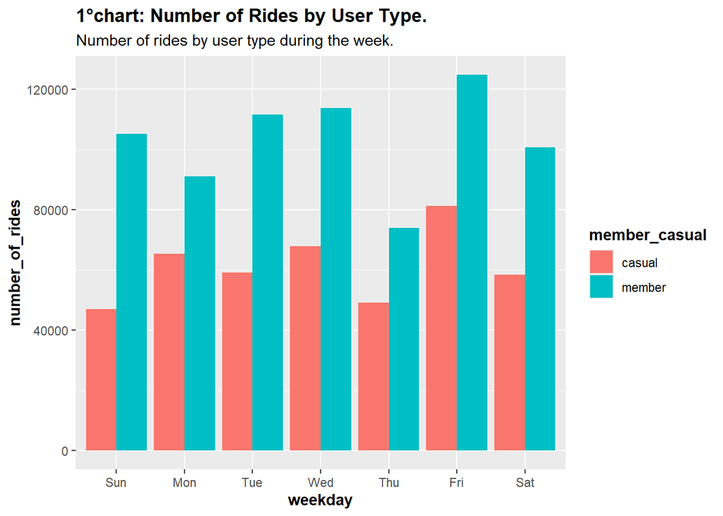

```r
dt_12_months_v2 %>%
mutate(weekday = wday(started_at, label = TRUE)) %>%
group_by(member_casual, weekday) %>%
summarise(number_of_rides = n()
,average_duration = mean(ride_length)) %>%
arrange(member_casual, weekday) %>%
ggplot(aes(x = weekday, y = number_of_rides, fill = member_casual)) +
geom_col(position = "dodge")+
scale_x_discrete(labels = c("Sun", "Mon", "Tue", "Wed", "Thu", "Fri", "Sat")) +
labs(title = "1°chart: Number of Rides by User Type.",
       subtitle = "Number of rides by user type during the week.")+
  theme(plot.title = element_text(face = "bold"),
          axis.title = element_text(face = "bold"),
        legend.title = element_text(face = "bold"))
```